# Reproducible Research: Peer Assessment 1

Minerva Goree

Saturday, August 09, 2014

### Global Options for this report

The following options are global for this whole analysis. It includes the packages required to run the analysis.

```r
require('knitr')
```

```r
require(ggplot2)
opts_chunk$set(echo = TRUE, results = "asis")
##options(digits=2)
options("scipen"=100, "digits"=2)
```

### Loading and preprocessing the data

The first thing before starting to analyze data is to load data. You can download the data from https://d396qusza40orc.cloudfront.net/repdata%2Fdata%2Factivity.zip to your local directory. The code below assumes the zipped folder is in your local directory.

```r
unzip("./activity.zip")
activity <- read.csv("activity.csv", header=TRUE)
#Change dates from factor to date format. This is the initial transformation needed.
activity$date <- as.character(as.factor(activity$date))
activity$date <- as.Date(activity$date)
```

### What is mean total number of steps taken per day?

For this part of the assignment we ignore the missing values of the dataset. We first create a historgram of the total number of steps taken each day:

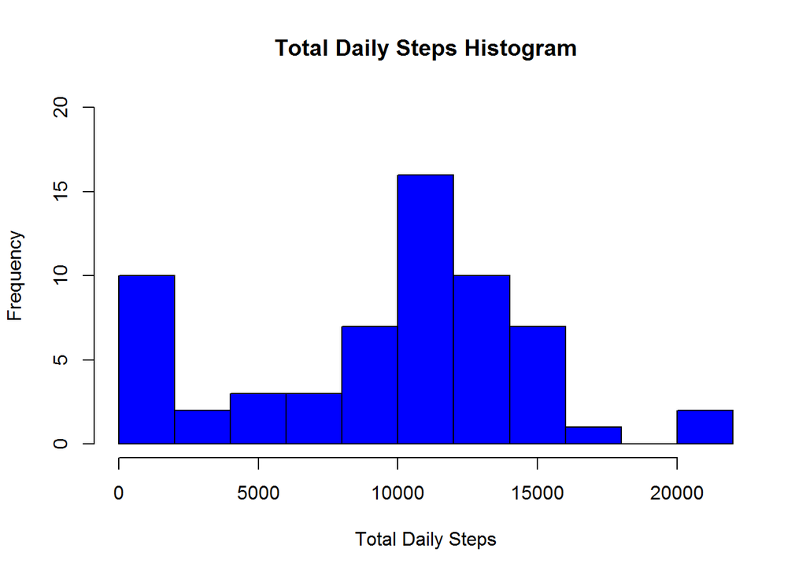

```r
totalSteps <- with(activity, aggregate(steps, by=list(date), FUN=sum, na.rm=TRUE))
names(totalSteps)<- c("date","steps")
stepsHist <- hist(totalSteps$steps,main="Total Daily Steps Histogram",xlab="Total Daily Steps", col="blue",ylim=c(0,20),breaks=10)
```

The next step is to calculate the mean and median total number of steps taken per day.

```r
stepsMean <-mean(totalSteps$steps)
stepsMedian <- median(totalSteps$steps)
```

- Daily Steps Mean: 9354.23
- Daily Steps Median: 10395

### What is the average daily activity pattern?

The next important step is to make a time series plot of the 5-minute interval and the average number of steps taken. All averaged out across all days of the week.

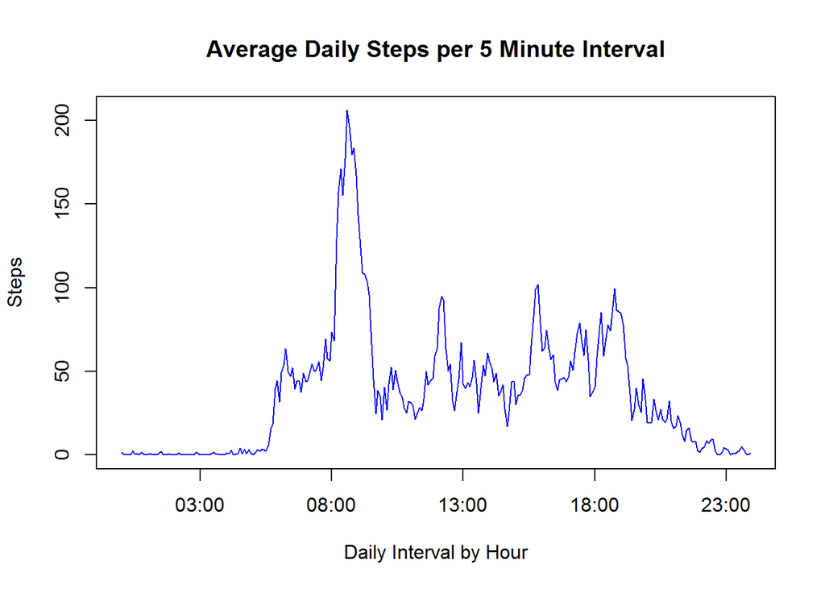

```r
activityData <- activity
activityData$time <- sprintf("%04d:00",activityData$interval)# step 1 to change interval to time
activityData$time <- gsub("(\\d\\d)(\\d\\d)","\\1:\\2",activityData$time)#step 2 to change to time
activityData$dateTime <- as.POSIXct(paste(activityData$date,activityData$time),format="%Y-%m-%d %H:%M:%S") # step 3, change char to date and time.
activityData$time <- as.POSIXct(activityData$time,format="%H:%M:%S") #step 4, change char to time.
interval <- with(activityData, aggregate(steps, by=list(time), FUN=mean, na.rm=TRUE))#daily average of steps.
names(interval)<- c('time','steps') #make sure we have the right column names
plot(interval$time,interval$steps,type="l",col="blue", main="Average Daily Steps per 5 Minute Interval", xlab="Daily Interval by Hour",ylab="Steps")
```

```r
maxSteps <- which.max(interval[,2]) #max steps in an interval
maxSteps <- interval[maxSteps,]
maxSteps$steps <- round(maxSteps$steps,digits=0)
```

We now figure out what 5-minute interval in the dataset on average is the maximum number of steps: The maximum steps are found on interval (time) **835** at about **206** steps.

### Imputing missing values

Calculate how many rows have missing values (NAs).

```r
notComplete <- activity[!complete.cases(activity),]
notComplete2 <- nrow(notComplete)
activityRows <- nrow(activity)
percentIncomplete <- notComplete2/activityRows*100
```

The number of incomplete rows in our data set is **2304** , which is **13.11** % of our total data set.

Below is the deviced plan for filling the missing values in the dataset: To take care of the missing values I will use the mean value of each interval to fill in the missing NAs. Below is the new dataset created to fill in the missing data with the mean. You will also see the histogram where the amount of data with zero has greatly diminished as we have replaced missing data with the interval average.

```r
activityData2 <- activityData
#we first find themean of steps by interval
interval2 <- with(activityData2, aggregate(steps, by=list(interval), FUN=mean, na.rm=TRUE))
names(interval2)<- c('interval','steps')#makes sure we have the right names in our columns
##This matches all the missing data with the mean average of each interval and replaces missing info.
activityData2$steps[is.na(activityData2$steps)] <- interval2[match(activityData2$interval, interval2$interval),2]
```

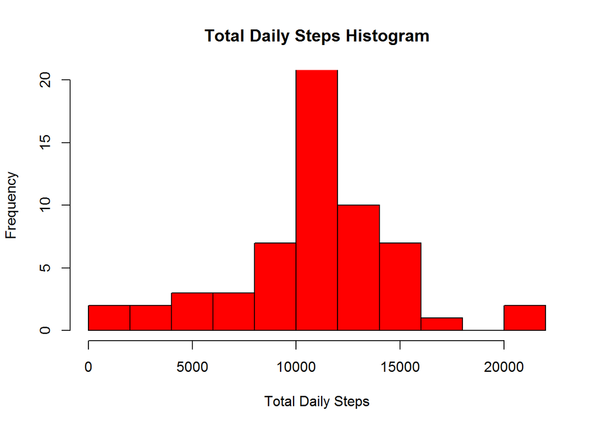

```r
#we then sum steps by date
totalSteps2 <- with(activityData2, aggregate(steps, by=list(date), FUN=sum, na.rm=TRUE))
names(totalSteps2)<- c("date","steps")
#now we build a histogram with the total of steps per daily interval
stepsHist2 <- hist(totalSteps2$steps,main="Total Daily Steps Histogram",xlab="Total Daily Steps", col="red",ylim=c(0,20),breaks=10)
```

We then calculate the new mean and median for our new dataset that no longer has NAs.

```r
stepsMean2 <- round(mean(totalSteps2$steps),0)
stepsMedian2 <- round(median(totalSteps2$steps),0)
```

- Daily Steps Mean: 10766
- Daily Steps Median: 10766

### Are there differences in activity patterns between weekdays and weekends?

Below I created a new factor variable with two levels for weekday and weekend.

```r
activityData2$DayOfTheWeek <- weekdays(activityData2$date)
activityData2$Day <- ifelse(activityData2$DayOfTheWeek == "Sunday"|activityData2$DayOfTheWeek == "Saturday","WeekEnd","WeekDay")
activityData2$Day <- as.factor(as.character(activityData2$Day))
```

I have then produced code to average the steps by daily interval and plot it in a panel of weekend and weekday:

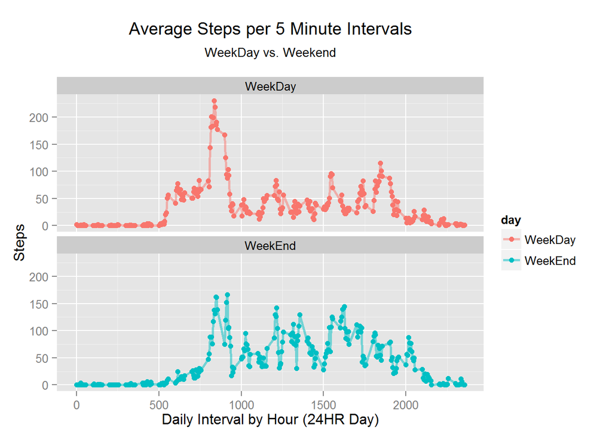

```r
interval3 <- with(activityData2, aggregate(steps, by=list(interval,Day), FUN=mean))
names(interval3)<- c('interval','day','steps')
weeklyPlot <-ggplot(interval3,aes(x=interval,y=steps)) +
        geom_line(aes(color=day), size= 1,alpha=1/2) +
        geom_point(aes(color=day)) +
        facet_wrap(~ day, ncol=1)+
        labs(x="Daily Interval by Hour (24HR Day)", y="Steps") +
        labs(title= expression(atop("Average Steps per 5 Minute Intervals", atop("WeekDay vs. Weekend"),"")))
print(weeklyPlot)
```